# R Programming

## You will learn about…

> 1. packages  
> 2. importing data  
> 3. exporting data  
> 4. tidying data

## Packages

> A bundle of functions, data sets, and help pages that you install in addition to the base R installation.

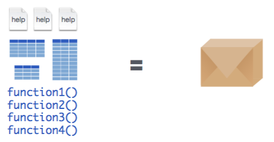

## Your Turn - #1

> Download the following packages:  
> `readxl`, `xlxs`, `tidyr`, `dplyr`

## Importing / Exporting Data

| File type | Import | Export |
| --- | --- | --- |
| text file (.csv) | `read.csv` | `write.csv` |
| text file (.tsv or .txt) | `read.delim` | `write.table` |
| Excel file (.xls or .xlsx) | `readxl::read_excel` | `xlsx::write.xls` |
| R object file (.rds) | `readRDS` | `saveRDS` |

## Your Turn - #2

> 1. load the iris data set  
> 2. what is this data measuring?

## Your Turn - #3

> 1. read in the `aircraft.csv` file with text set as factors  
> 2. read in the `aircraft.tsv` file with text set as character strings  
> 3. take a peek at what this data looks like

## Your Turn - #4

> 1. what are the worksheet names in the `aircraft.xlsx` file?  
> 2. read in the `Trainers` worksheet  
> 3. take a peek at what this data looks like  
> 4. how many NAs exist; omit all NAs in this data set  
> 5. create a new variable that is cost / flying hour  
> 6. save this filtered data as `trainers.xlsx`

## Your Turn - #5

> 1. save your previous trainers data set as `trainers.rds`  
> 2. now read that file back in

## Tidy Data

> 1. One variable per column

> 2. One observation per row

```
##                 Type     MD   FY     FH   Gallons       Cost
## 1             Bomber    B-1 1996  30313  75786560   93524779
## 2             Bomber    B-1 1997  28618  72676185   92068261
## 3             Bomber    B-1 1998  27604  72451149  104797803
## 4             Bomber    B-1 1999  26705  66515927   92619334
## 5             Bomber    B-1 2000  28412  73422395   79210775
## 6             Bomber    B-1 2001  28458  74084543  115717075
## 7             Bomber    B-1 2002  29980  76390373  117229534
## 8             Bomber    B-1 2003  24890  61677899   89421068
## 9             Bomber    B-1 2004  31517  88589818  122666632
## 10            Bomber    B-1 2005  25258  65602526  145587688
## 11            Bomber    B-1 2006  23562  57176253  195398867
## 12            Bomber    B-1 2007  28028  72304596  225257402
## 13            Bomber    B-1 2008  26423  65276902  286880846
## 14            Bomber    B-1 2009  26464  68222690  206673080
```

[output cut: 911 more lines]

## Tidy Data

Is this data tidy?

```
##     Type   MD  2006  2007  2008  2009  2010  2011  2012  2013  2014
## 1 Bomber  B-1 20163 24629 23024 23065 23398 24166 29292 25253 22204
## 2 Bomber  B-2  6100  6266  4074  4567  4638  4873  4955  4076  5070
## 3 Bomber B-52 28206 22484 20284 18765 18250 21727 21748 19309 21297
```

## Tidy Data

Is this data tidy?

```
##      Type   MD   FY  Output     Value
## 1  Bomber  B-1 2013      FH     25253
## 2  Bomber  B-1 2014      FH     22204
## 3  Bomber  B-2 2013      FH      4076
## 4  Bomber  B-2 2014      FH      5070
## 5  Bomber B-52 2013      FH     19309
## 6  Bomber B-52 2014      FH     21297
## 7  Bomber  B-1 2013 Gallons  85970844
## 8  Bomber  B-1 2014 Gallons  73145048
## 9  Bomber  B-2 2013 Gallons   7925422
## 10 Bomber  B-2 2014 Gallons   9638853
## 11 Bomber B-52 2013 Gallons  64933573
## 12 Bomber B-52 2014 Gallons  70891306
## 13 Bomber  B-1 2013    Cost 346054359
## 14 Bomber  B-1 2014    Cost 289357667
## 15 Bomber  B-2 2013    Cost  41433404
## 16 Bomber  B-2 2014    Cost  46326775
## 17 Bomber B-52 2013    Cost 209017819
## 18 Bomber B-52 2014    Cost 224248841
```

## Tidy Data

Is this data tidy?

```
##             AC   FY      Cost    FH   Gallons
## 1   Bomber B-1 1996  72753781 26914  88594449
## 2   Bomber B-1 1997  71297263 25219  85484074
## 3   Bomber B-1 1998  84026805 24205  85259038
## 4   Bomber B-1 1999  71848336 23306  79323816
## 5   Bomber B-1 2000  58439777 25013  86230284
## 6   Bomber B-1 2001  94946077 25059  86892432
## 7   Bomber B-1 2002  96458536 26581  89198262
## 8   Bomber B-1 2003  68650070 21491  74485788
## 9   Bomber B-1 2004 101895634 28118 101397707
## 10  Bomber B-1 2005 124816690 21859  78410415
## 11  Bomber B-1 2006 174627869 20163  69984142
## 12  Bomber B-1 2007 204486404 24629  85112485
## 13  Bomber B-1 2008 266109848 23024  78084791
## 14  Bomber B-1 2009 185902082 23065  81030579
```

[output cut: 43 more lines]

## Tidy Data with `tidyr`

`tidyr` is a package that reshapes the layout of data frames:

`gather()`: transforms data from wide to long

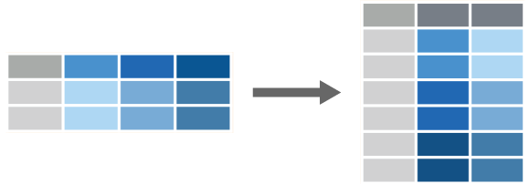

`spread()`: transforms data from long to wide

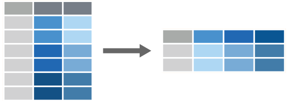

`separate()`: splits a single column into multiple columns

`unite()`: combines multiple columns into a single column

## Your Turn - #6

> 1. import the `bomber_wide.rds` file  
> 2. turn this into long format

## Your Turn - #7

> 1. import the `bomber_long.rds` file  
> 2. turn this into a wider format with Cost, FH, & Gallons as variables

## Your Turn - #8

> 1. import the `bomber_combined.rds` file  
> 2. separate the AC variable into "Type" and "MD"

## Your Turn - #9

> 1. import the `bomber_prefix.rds` file  
> 2. unite the "prefix" and "number" variables into an "MD" variable

## Pipe Operator: `%>%`

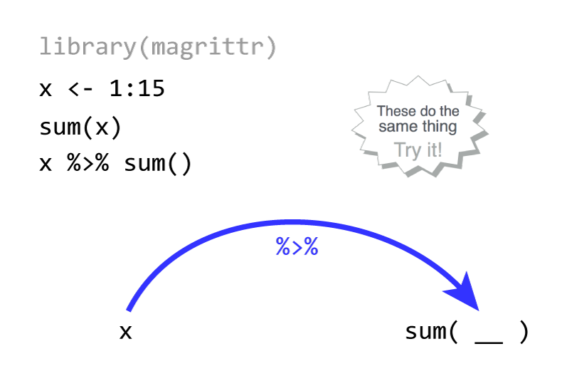

## Your Turn - #10

> 1. import the `bomber_mess.rds` file  
> 2. tidy this data to make it look like:

```
##      Type   MD   FY      Cost    FH   Gallons
## 1  Bomber  B-1 1996  72753781 26914  88594449
## 2  Bomber  B-1 1997  71297263 25219  85484074
## 3  Bomber  B-1 1998  84026805 24205  85259038
## 4  Bomber  B-1 1999  71848336 23306  79323816
## 5  Bomber  B-1 2000  58439777 25013  86230284
## 6  Bomber  B-1 2001  94946077 25059  86892432
## 7  Bomber  B-1 2002  96458536 26581  89198262
## 8  Bomber  B-1 2003  68650070 21491  74485788
## 9  Bomber  B-1 2004 101895634 28118 101397707
## 10 Bomber  B-1 2005 124816690 21859  78410415
## 11 Bomber  B-1 2006 174627869 20163  69984142
## 12 Bomber  B-1 2007 204486404 24629  85112485
## 13 Bomber  B-1 2008 266109848 23024  78084791
## 14 Bomber  B-1 2009 185902082 23065  81030579
```

[output cut: 43 more lines]

## Learn More

> https://afit-r.github.io

> » Importing/Exporting Data Section  
> » Simplify Code with `%>%` Section  
> » Reshape Data with `tidyr` Section